# Political Analytics Research Paper: Personal COVID-19 Experiences and Voting Behavior in the 2020 U.S. Election

Kelsey Quigg

Fall 2022

## Introduction

This paper will investigate the following question: leading up to the 2020 U.S. presidential election, what effect did voters’ personal experiences with COVID-19 have on their attitudes towards incumbent Donald Trump? Multiple regression will be used to address this question.

The coronavirus pandemic is a unique issue due to its direct, immediate effects on voters’ lives. Exploring this question will offer insight into how voters’ individual experiences may have shaped the 2020 election.

### Hypotheses

I anticipate that voters with personal experience with COVID-19 will view Donald Trump less favorably. Since Trump was the incumbent president at the beginning of the coronavirus pandemic, some voters may consider his administration responsible for failing to prevent the spread of the disease (ex. by not requiring a national mask mandate). Those who witnessed its effects firsthand may harbor resentment towards Trump.

**H1**: Respondents from households that had been exposed to COVID-19, indicated by either a positive test or symptoms, will report more negative attitudes towards Donald Trump than those who did not.

However, I do not expect personal experience with COVID-19 to overpower the preexisting beliefs of intense partisans. Strong Democrats are likely to dislike Donald Trump, even in the absence of negative experiences that they could potentially blame on his policies. Likewise, strong Republicans are likely to favor Trump even if they were negatively impacted by the pandemic.

**H2**: Respondents with strong partisan identities will hold opinions on Donald Trump that reflect the stances of their parties (i.e. negative attitudes from Democrats and positive attitudes from Republicans), regardless of their experience with COVID-19.

## Description of Data

```r
setwd("/Users/kelseyquigg/Dropbox/Political Analytics PS5530")
anes <- read.csv("anes_timeseries_2020.csv")
pacman::p_load(tidyverse, psych, modeest, interactions, ggplot2, stargazer)
dim(anes)
```

```
## [1] 8280 1771
```

## Relevant Variables

### Dependent Variable

#### Trump Feeling Thermometer

The dependent variable in this investigation is the feeling thermometer for then-president Donald Trump. Respondents were given a series of names of political leaders, such as both parties’ presidential candidates and running mates, and asked to rate them on a continuous scale from 0 to 100 degrees. On this scale, 50 degrees represents neutral feelings. Any rating below 50 degrees indicates cold or negative feelings, and any rating above 50 degrees indicates warm or positive feelings. For this variable and all subsequent variables, respondents who refused to answer have been coded as missing values.

```r
anes <- rename(anes, trump_ft = V201152)
anes$trump_ft[anes$trump_ft==-9] <- NA
describe(anes$trump_ft)
```

|  | vars | n | mean | sd | median | trimmed | mad | min | max | range | skew | kurtosis | se |
| --- | --- | --- | --- | --- | --- | --- | --- | --- | --- | --- | --- | --- | --- |
| X1 | 1 | 8048 | 40.44061 | 40.31091 | 30 | 38.05373 | 44.478 | 0 | 100 | 100 | 0.29518 | -1.605662 | 0.4493437 |

```r
mfv(anes$trump_ft, na_rm=TRUE) #Mode
```

```
## [1] 0
```

As evidenced by Figure 1, opinions towards Donald Trump leading up to the 2020 presidential election were polarized. The modal response was 0 degrees (strongly negative feelings), resulting in a heavily right-skewed distribution. However, there is a smaller spike around 100 degrees (strongly positive feelings). This indicates that most respondents either strongly disliked or strongly liked Donald Trump. The mean is 40.4 degrees, and the median is 30 degrees.

Based on the skewed distribution of the Trump feeling thermometer, ordinary least squares may not be the most appropriate type of regression for this dependent variable. This will be discussed further in the regression section of the paper.

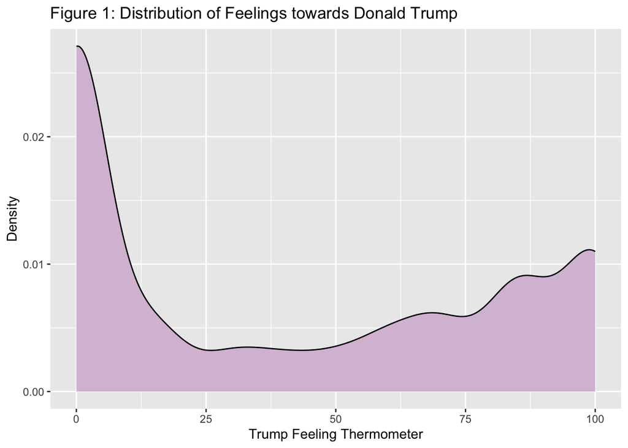

```r
ggplot(anes, aes(trump_ft)) +
  geom_density(fill="thistle") +
  xlab("Trump Feeling Thermometer") +
  ylab("Density") +
  ggtitle("Figure 1: Distribution of Feelings towards Donald Trump")
```

### Independent Variables

#### Household COVID Exposure: Positive Tests and Symptoms

The primary independent variable in this study is respondents’ personal experience with COVID-19. The ANES includes two binary measures of this experience: whether or not anyone in the respondent’s household received a positive COVID-19 test, and whether or not anyone in the respondent’s household was suspected of having COVID-19 based on symptoms. Both of these measures will be incorporated into the regression model.

For both measures, household COVID-19 exposure was relatively uncommon. Only 3.5% of respondents answered that someone in their household had received a positive test, and 12.2% answered that someone in their household displayed symptoms.

```r
## Someone in Household Tested Positive for COVID-19
anes$pos_covid[anes$V201624==1] <- 1
anes$pos_covid[anes$V201624==2] <- 0
anes$pos_covid[anes$V201624==-9] <- NA
anes$pos_covid[anes$V201624==-5] <- NA
prop.table(table(anes$pos_covid))
```

```
##
##        0        1
## 0.964923 0.035077
```

```r
## Someone in Household Suspected of Having COVID-19
anes$covid_symptoms[anes$V201625==1] <- 1
anes$covid_symptoms[anes$V201625==2] <- 0
anes$covid_symptoms[anes$V201625==-9] <- NA
anes$covid_symptoms[anes$V201625==-5] <- NA
prop.table(table(anes$covid_symptoms))
```

```
##
##         0         1
## 0.8780398 0.1219602
```

Figure 2a compares attitudes towards Donald Trump among respondents from households with a positive COVID-19 test and those without. The range and interquartile range of feeling thermometer values seems about the same for both groups. However, the median feeling thermometer rating is about 10 degrees warmer among those with a positive COVID-19 test in their household than those without.

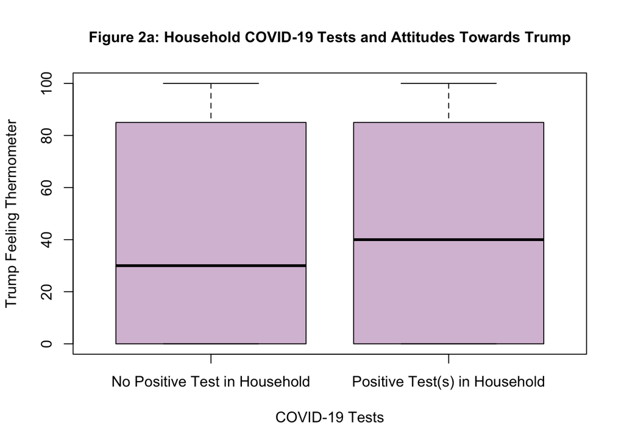

```r
boxplot(trump_ft ~ pos_covid, data=anes, names=c("No Positive Test in Household",
                                                 "Positive Test(s) in Household"),
        xlab="COVID-19 Tests",
        ylab="Trump Feeling Thermometer",
        main="Figure 2a: Household COVID-19 Tests and Attitudes Towards Trump",
        col="thistle",
        cex.main=1)
```

These two boxplots indicate that the two measures of COVID-19 experience may have opposite effects on people’s attitudes towards Donald Trump. On average, people who experienced a positive COVID-19 test in their household felt more positively towards Trump than those who did not. Meanwhile, people with a household member who displayed COVID-19 symptoms felt more negatively on average than those who did not. These distinctions underscore the importance of investigating both of these measures of COVID-19 exposure in this paper’s regression models.

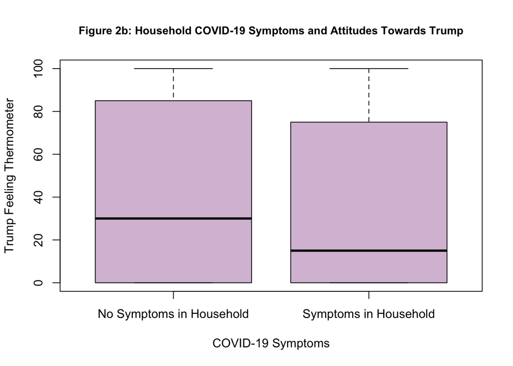

```r
boxplot(trump_ft ~ covid_symptoms, data=anes, names=c("No Symptoms in Household",
                                                      "Symptoms in Household"),
        xlab="COVID-19 Symptoms",
        ylab="Trump Feeling Thermometer",
        main="Figure 2b: Household COVID-19 Symptoms and Attitudes Towards Trump",
        col="thistle",
        cex.main=0.9)
```

#### Approval of Presidential COVID-19 Response

Another relevant independent variable is respondents’ evaluation of Trump’s response to the coronavirus pandemic. Respondents were asked whether or not they approved of the president’s handling of the situation, and whether or not they feel strongly about that stance. The majority of respondents said that they strongly disapproved (55.7%). The next most common sentiment was strong approval (25.6%). At first glance, this trend seems similar to the Trump feeling thermometer.

```r
## Approval of President's Handling of COVID-19
anes$pres_covid[anes$V201144x==4] <- 0
anes$pres_covid[anes$V201144x==3] <- 1
anes$pres_covid[anes$V201144x==2] <- 2
anes$pres_covid[anes$V201144x==1] <- 3
anes$pres_covid[anes$V201144x==-2] <- NA
anes$pres_covid_label <- factor(anes$pres_covid,
                          levels = c(0,1,2,3),
                          labels = c("Strongly disapprove",
                                     "Disapprove",
                                     "Approve",
                                     "Strongly approve"))
prop.table(table(anes$pres_covid_label))
```

```
##
## Strongly disapprove          Disapprove             Approve    Strongly approve
##           0.5570527           0.0643360           0.1228454           0.2557660
```

#### Party Identification

It is important to account for alternative explanations for respondents’ attitudes towards Trump leading up to the 2020 presidential election. For example, respondents may simply form their opinions along party lines rather than based on a specific issue like COVID-19. This would align with the finding that most people viewed him either strongly positively or strongly negatively.

The ANES measures party identification on a 7-point categorical scale. Strong Democrats are coded as 1, Independents are coded as 4, and strong Republicans are coded as 7. These responses have all been moved down by one point to facilitate interpretation of the regression model’s intercept.

The most common responses in the sample were strong Democrats (23.8%) and strong Republicans (21.0%).

```r
anes$pid[anes$V201231x==1] <- 0
anes$pid[anes$V201231x==2] <- 1
anes$pid[anes$V201231x==3] <- 2
anes$pid[anes$V201231x==4] <- 3
anes$pid[anes$V201231x==5] <- 4
anes$pid[anes$V201231x==6] <- 5
anes$pid[anes$V201231x==7] <- 6
anes$pid[anes$V201231x==-9] <- NA
anes$pid[anes$V201231x==-8] <- NA
anes$pid_label <- factor(anes$pid,
                   levels = c(0,1,2,3,4,5,6),
                   labels = c("Strong Democrat", "Not very strong Democrat",
                              "Independent-Democrat", "Independent",
                              "Independent-Republican",
                              "Not very strong Republican",
                              "Strong Republican"))
prop.table(table(anes$pid_label))
```

```
##
##            Strong Democrat   Not very strong Democrat
##                  0.2378411                  0.1091571
##       Independent-Democrat                Independent
##                  0.1182535                  0.1174045
##     Independent-Republican Not very strong Republican
##                  0.1066101                  0.1009096
##          Strong Republican
##                  0.2098241
```

### Control Variables

#### Age

The remaining variables will be used to control for demographic differences. Respondents’ ages were measured as a continuous variable ranging from 18 to 80 years old. All respondents above 80 years old were grouped together with 80-year-olds by the ANES. Both the mean and median ages of respondents in this dataset are 52 when rounded.

```r
anes <- rename(anes, age = V201507x)
anes$age[anes$age==-9] <- NA
describe(anes$age)
```

|  | vars | n | mean | sd | median | trimmed | mad | min | max | range | skew | kurtosis | se |
| --- | --- | --- | --- | --- | --- | --- | --- | --- | --- | --- | --- | --- | --- |
| X1 | 1 | 7932 | 51.58522 | 17.20718 | 52 | 51.6976 | 22.239 | 18 | 80 | 62 | -0.06863582 | -1.142777 | 0.193205 |

#### Education

Respondents’ level of education is measured on an ordinal scale in this dataset. It ranges from less than a high school education to a professional or doctoral degree. The modal category is a bachelor’s degree (25.2% of respondents).

```r
anes$education[anes$V201510==1] <- 0
anes$education[anes$V201510==2] <- 1
anes$education[anes$V201510==3] <- 2
anes$education[anes$V201510==4] <- 3
anes$education[anes$V201510==5] <- 3
anes$education[anes$V201510==6] <- 4
anes$education[anes$V201510==7] <- 5
anes$education[anes$V201510==8] <- 6
anes$education[anes$V201510==-9] <- NA
anes$education[anes$V201510==-8] <- NA
anes$education[anes$V201510==95] <- NA
anes$education_label <- factor(anes$education,
                          levels = c(0,1,2,3,4,5,6),
                          labels = c("Less than high school credential",
                                     "High school diploma or equivalent",
                                     "Some college but no degree",
                                     "Associate degree", "Bachelor’s degree",
                                     "Master’s degree",
                                     "Professional or doctoral degree"))
prop.table(table(anes$education_label))
```

```
##
##  Less than high school credential High school diploma or equivalent
##                        0.04614063                        0.16394650
##        Some college but no degree                  Associate degree
##                        0.20665112                        0.13572217
##                 Bachelor’s degree                   Master’s degree
##                        0.25217818                        0.14541662
##   Professional or doctoral degree
##                        0.04994478
```

#### Race

For this investigation, race has been coded with four categories: white, black, hispanic, and other races. The vast majority of respondents in this dataset are white (72.9%).

```r
anes$race[anes$V201549x==-9] <- NA
anes$race[anes$V201549x==-8] <- NA
anes$race[anes$V201549x==1] <- 0
anes$race[anes$V201549x==2] <- 1
anes$race[anes$V201549x==3] <- 2
anes$race[anes$V201549x > 3] <- 3
anes$race_label <- factor(anes$race,
                    levels = c(0,1,2,3),
                    labels = c("White", "Black", "Hispanic", "Other Race"))
prop.table(table(anes$race_label))
```

```
##
##      White      Black   Hispanic Other Race
## 0.72915138 0.08877476 0.09317682 0.08889704
```

#### Sex

Sex has been coded as a binary variable measuring whether or not respondents are female. Most of the respondents in this sample are female (54.2%).

```r
anes$female[anes$V201600==2] <- 1
anes$female[anes$V201600==1] <- 0
anes$female[anes$V201600==-9] <- NA
prop.table(table(anes$female))
```

```
##
##         0         1
## 0.4581761 0.5418239
```

#### Region

The ANES includes the state in which each respondent is registered to vote. In order to simplify interpretation, each state has been grouped into the four main regions defined by the U.S. Census (United States Census Bureau 2022).  
• The northeast consists of Connecticut, Maine, Massachusetts, New Hampshire, New Jersey, New York, Pennsylvania, Rhode Island and Vermont.  
• The midwest consists of Illinois, Indiana, Iowa, Kansas, Michigan, Minnesota, Missouri, Nebraska, North Dakota, Ohio, South Dakota, and Wisconsin.  
• The south consists of Alabama, Arkansas, Delaware, District of Columbia, Florida, Georgia, Kentucky, Louisiana, Maryland, Mississippi, North Carolina, Oklahoma, South Carolina, Tennessee, Texas, Virginia, and West Virginia.  
• The west consists of Alaska, Arizona, California, Colorado, Hawaii, Idaho, Montana, Nevada, New Mexico, Oregon, Utah, Washington, and Wyoming.  
The region with the most respondents is the south (37.0%).

```r
anes$region[anes$V202054x < 0] <- NA

anes$region[anes$V202054x==9] <- 0
anes$region[anes$V202054x==23] <- 0
anes$region[anes$V202054x==25] <- 0
anes$region[anes$V202054x==33] <- 0
anes$region[anes$V202054x==34] <- 0
anes$region[anes$V202054x==36] <- 0
anes$region[anes$V202054x==42] <- 0
anes$region[anes$V202054x==44] <- 0
anes$region[anes$V202054x==50] <- 0

anes$region[anes$V202054x==17] <- 1
anes$region[anes$V202054x==18] <- 1
anes$region[anes$V202054x==19] <- 1
anes$region[anes$V202054x==20] <- 1
anes$region[anes$V202054x==26] <- 1
anes$region[anes$V202054x==27] <- 1
anes$region[anes$V202054x==29] <- 1
anes$region[anes$V202054x==31] <- 1
anes$region[anes$V202054x==38] <- 1
anes$region[anes$V202054x==39] <- 1
anes$region[anes$V202054x==46] <- 1
anes$region[anes$V202054x==55] <- 1

anes$region[anes$V202054x==1] <- 2
anes$region[anes$V202054x==5] <- 2
anes$region[anes$V202054x==10] <- 2
anes$region[anes$V202054x==11] <- 2
anes$region[anes$V202054x==12] <- 2
anes$region[anes$V202054x==13] <- 2
anes$region[anes$V202054x==21] <- 2
anes$region[anes$V202054x==22] <- 2
anes$region[anes$V202054x==24] <- 2
anes$region[anes$V202054x==28] <- 2
anes$region[anes$V202054x==37] <- 2
anes$region[anes$V202054x==40] <- 2
anes$region[anes$V202054x==45] <- 2
anes$region[anes$V202054x==47] <- 2
anes$region[anes$V202054x==48] <- 2
anes$region[anes$V202054x==51] <- 2
anes$region[anes$V202054x==54] <- 2

anes$region[anes$V202054x==2] <- 3
anes$region[anes$V202054x==4] <- 3
anes$region[anes$V202054x==6] <- 3
anes$region[anes$V202054x==8] <- 3
anes$region[anes$V202054x==15] <- 3
anes$region[anes$V202054x==16] <- 3
anes$region[anes$V202054x==30] <- 3
anes$region[anes$V202054x==32] <- 3
anes$region[anes$V202054x==35] <- 3
anes$region[anes$V202054x==41] <- 3
anes$region[anes$V202054x==49] <- 3
anes$region[anes$V202054x==53] <- 3
anes$region[anes$V202054x==56] <- 3

anes$region_label <- factor(anes$region,
                            levels=c(0,1,2,3),
                            labels=c("Northeast","Midwest","South","West"))
prop.table(table(anes$region_label))
```

```
##
## Northeast   Midwest     South      West
## 0.1677776 0.2450716 0.3695930 0.2175578
```

## Regression

### Model 1: No Interactions

The first regression will include the following explanatory variables: household COVID-19 exposure (measured in terms of both positive tests and symptoms), approval of Trump’s COVID-19 response, party identification, age, education, race, sex, and region.

Due to the skewed nature of the dependent variable of this investigation (the Trump feeling thermometer), only using an ordinary least squares regression model might not provide the complete picture of these relationships. In order to combat this problem, the results of the OLS model will be displayed alongside the results of a generalized linear model. The statistical significance of estimates in both models will be compared in order to identify any variables that may not maintain their relevance in the GLM.

```r
model.1a <- lm(trump_ft ~ pos_covid + covid_symptoms + pres_covid + pid + age +
                 education + race_label + female + region_label, data=anes)
model.1b <- glm(trump_ft ~ pos_covid + covid_symptoms + pres_covid + pid + age +
                  education + race_label + female + region_label,
                family="quasipoisson", data=anes)
```

```r
stargazer(model.1a, model.1b,
          title="Table 1: Regression Results without Interactions",
          dep.var.labels="Trump Feeling Thermometer",
          column.labels=c("OLS", "GLM"),
          column.separate=c(1,1),
          column.sep.width="2pt",
          covariate.labels=c("Positive COVID-19 Test in Household",
                             "COVID-19 Symptoms in Household",
                             "Approval of Trump's COVID-19 Response",
                             "Party ID", "Age", "Education", "Black",
                             "Hispanic", "Other Race", "Female", "Midwest",
                             "South", "West"),
          no.space=TRUE,
          multicolumn=TRUE,
          df=FALSE,
          model.names=FALSE,
          model.numbers=FALSE,
          header=FALSE,
          type="latex",
          notes="Standard errors in parentheses")
```

[output not shown]

Table 1 displays the results of the first regression using both OLS and GLM. Statistical significance will be assessed at the 0.05 level.

#### Intercept

Based on the intercept, we can predict that someone who has no experience with COVID-19 in their household, strongly disapproves of the Trump administration’s response to COVID-19, is a strong Democrat, is 0 years old, has less than a high school education, is white, is male, and is from the northeast will rate Trump extremely low on the feeling thermometer scale (2.84 degrees). This estimate is statistically significant (p=0.009). However, it is not very practically useful since 0-year-olds are not part of the population of interest.

#### COVID-19 Personal Experiences

Interestingly, the effects of having a positive COVID-19 test in one’s household and having COVID-19 symptoms in one’s household are reversed. Respondents from households with a positive COVID-19 test are expected to view Trump 1.05 degrees more positively than those without, all else equal. Meanwhile, respondents from households with COVID-19 symptoms are expected to view Trump 1.31 degrees more negatively than those without, all else equal. However, neither of these estimates are statistically significant at the 0.05 level, in either the OLS or the GLM regressions.

#### Approval of the Trump Administration’s Response to COVID-19

The most practically significant estimate in this model is approval of Trump’s response to COVID-19. For every one-unit increase along the four-point approval scale, moving from the “strongly disapprove” to “strongly approve” side of the spectrum, feelings towards Trump become more positive by 19.56 degrees, all else equal. This estimate is statistically significant (p<0.01) for both OLS and GLM.

#### Party Identification

For every one-unit increase along the seven-point party identification scale, moving from the “strong Democrat” to the “strong Republican” end of the spectrum, feelings towards Trump become more positive by 5.82 degrees. This variable is statistically significant in both the OLS regression and the GLM regression (p<0.01).

#### Age

For every one-year increase in age, feelings towards Trump become more positive by 0.057 degrees, all else equal. While this estimate is statistically significant in the OLS regression (p<0.01), age is not significant in the GLM regression (p=0.5118). It is also not very practically significant in the OLS model, since it would take 10 years for someone’s feelings towards Trump to change by even half of a degree. Additionally, the direction of this trend is reversed in the generalized linear model.

#### Education

For every one-unit increase in education level, feelings towards Trump become more negative by 1.18 degrees, all else equal. This variable is statistically significant in both the OLS and GLM regressions (p<0.01).

#### Race

Compared to white voters:  
•Black voters are expected to view Trump 0.36 degrees more positively, all else equal. This variable is not statistically significant for either the OLS (p=0.66) or the GLM regressions (p=0.74). Additionally, the direction of the effect is reversed in the GLM.  
•Hispanic voters are expected to view Trump 1.63 degrees more positively, all else equal. This variable is statistically significant in both the OLS (p=0.04) and GLM regressions (p=0.04).  
•Voters who are not white, black, or hispanic are expected to view Trump 3.89 degrees more positively, all else equal. This variable is statistically significant in both the OLS (p<0.01) and GLM regressions (p<0.01). It is also the most practically significant estimate out of all of the race categories.

#### Sex

Women are expected to view Trump 0.44 degrees more negatively than men, all else equal. However, this variable is not statistically significant in either the OLS (p=0.30) or the GLM regressions (p=0.07). It is also not very practically significant, since the difference between the two groups is less than half of a degree.

##### Region

Compared to voters from the northeast:  
•Voters from the midwest are expected to view Trump 0.18 degrees more negatively, all else equal.  
•Voters from the south are expected to view Trump 0.50 degrees more positively, all else equal. However, the direction of this trend is reversed in the GLM.  
•Voters from the west are expected to view Trump 1.14 degrees more negatively, all else equal.  
None of the estimates for region were statistically significant in either the OLS or GLM regressions. Additionally, most of them were not practically significant, because only the comparison between the west and the northeast resulted in a difference greater than one degree.

#### R-Squared

The R-squared for this model indicates that the variation of the selected independent variables explain 83% of the variation in attitudes towards Trump. Therefore, this model is a good fit for understanding which factors influenced attitudes towards Trump leading up to the 2020 election.

### Interaction Between Party and COVID Exposure

There is a possibility that party identification affects the relationship between personal experiences with COVID-19 and attitudes towards Trump. For example, strong Democrats may be more likely to blame their experiences with the pandemic on decisions made by the Trump administration. Meanwhile, strong Republicans with similar experiences may blame other government entities, such as Congress or state and local governments. Two interaction effects will be added to the previous model: one between party identification and household positive COVID-19 tests, and one between party identification and household COVID-19 symptoms.

```r
model.2a <- lm(trump_ft ~ pos_covid + covid_symptoms + pres_covid + pid + age +
                 education + race_label + female + region_label +
                 pid*pos_covid + pid*covid_symptoms, data=anes)
model.2b <- glm(trump_ft ~ pos_covid + covid_symptoms + pres_covid + pid + age +
                  education + race_label + female + region_label +
                  pid*pos_covid + pid*covid_symptoms,
                family="quasipoisson", data=anes)
```

```r
stargazer(model.2a, model.2b,
          title="Table 2: Regression Results with Interactions",
          dep.var.labels="Trump Feeling Thermometer",
          column.labels=c("OLS", "GLM"),
          column.separate=c(1,1),
          column.sep.width="2pt",
          covariate.labels=c("Positive COVID-19 Test in Household",
                             "COVID-19 Symptoms in Household",
                             "Approval of Trump's COVID-19 Response",
                             "Party ID", "Age", "Education", "Black",
                             "Hispanic", "Other Race", "Female", "Midwest",
                             "South", "West",
                             "Party ID x Positive COVID-19 Test in Household",
                             "Party ID x COVID-19 Symptoms in Household"),
          no.space=TRUE,
          multicolumn=TRUE,
          df=FALSE,
          model.names=FALSE,
          model.numbers=FALSE,
          header=FALSE,
          type="latex",
          notes="Standard errors in parentheses")
```

[output not shown]

Table 2 contains the results of the updated regression models. In the OLS regression model, neither of the interactions are statistically significant. However, both of these variables are significant in the GLM model. Individuals with similar COVID-19 experiences but different party identifications may, therefore, hold different opinions on Donald Trump. The next series of graphs will analyze this possibility further.

It should be noted that the R-squared of the model with interaction effects is the same as the one without (0.83). Therefore, including these interaction effects does not greatly improve the fit of the model.

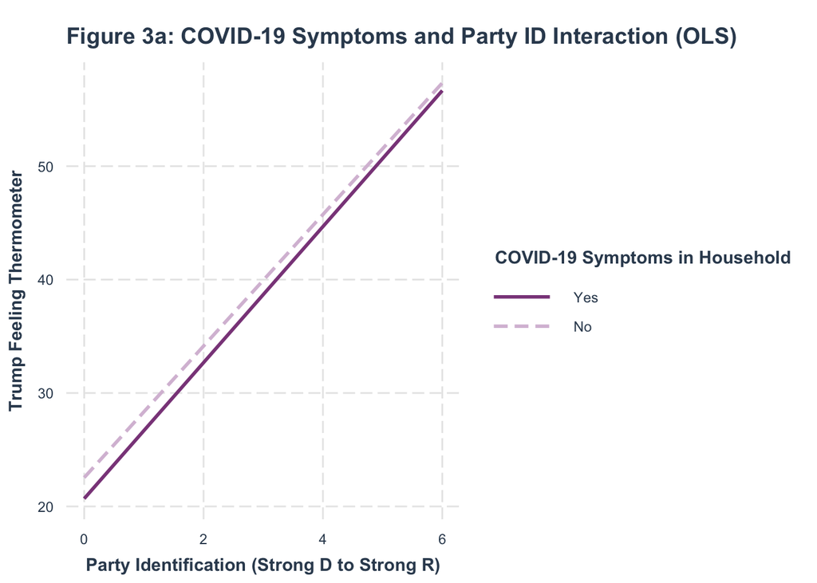

```r
fig.3a <- interact_plot(model.2a,
                        pred=pid,
                        modx=covid_symptoms,
                        main.title="Figure 3a: COVID-19 Symptoms and Party ID Interaction (OLS)",
                        x.label="Party Identification (Strong D to Strong R)",
                        y.label="Trump Feeling Thermometer",
                        legend.main="COVID-19 Symptoms in Household",
                        modx.labels=c("No", "Yes"),
                        colors=c("thistle","orchid4"),
                        pred.labels=c("Strong Democrat",
                                      "Independent-Democrat",
                                      "Independent-Republican",
                                      "Strong Republican"))
fig.3a
```

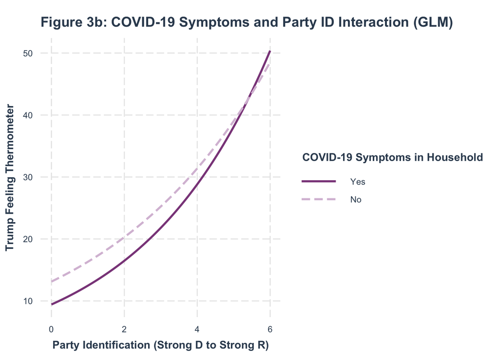

```r
fig.3b <- interact_plot(model.2b,
                        pred=pid,
                        modx=covid_symptoms,
                        main.title="Figure 3b: COVID-19 Symptoms and Party ID Interaction (GLM)",
                        x.label="Party Identification (Strong D to Strong R)",
                        y.label="Trump Feeling Thermometer",
                        legend.main="COVID-19 Symptoms in Household",
                        modx.labels=c("No", "Yes"),
                        colors=c("thistle","orchid4"))
fig.3b
```

Figure 3b shows the results of the interaction between party identification and household COVID-19 symptoms in the generalized linear model. Unlike the previous figure, this model indicates different outcomes for people who were exposed to COVID-19 symptoms in their household and those who were not based on party identification. Among strong Democrats, voters from households with COVID-19 symptoms hold slightly colder attitudes towards Trump than those without. Among strong Republicans, however, those with household COVID-19 symptoms hold warmer attitudes towards Trump than those without.

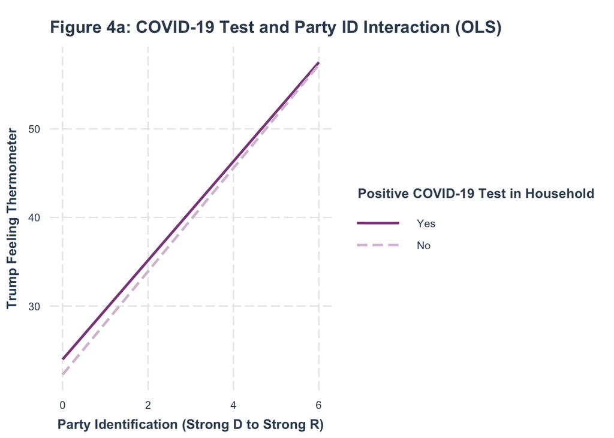

```r
fig.4a <- interact_plot(model.2a,
                        pred=pid,
                        modx=pos_covid,
                        main.title="Figure 4a: COVID-19 Test and Party ID Interaction (OLS)",
                        x.label="Party Identification (Strong D to Strong R)",
                        y.label="Trump Feeling Thermometer",
                        legend.main="Positive COVID-19 Test in Household",
                        modx.labels=c("No", "Yes"),
                        colors=c("thistle","orchid4"))
fig.4a
```

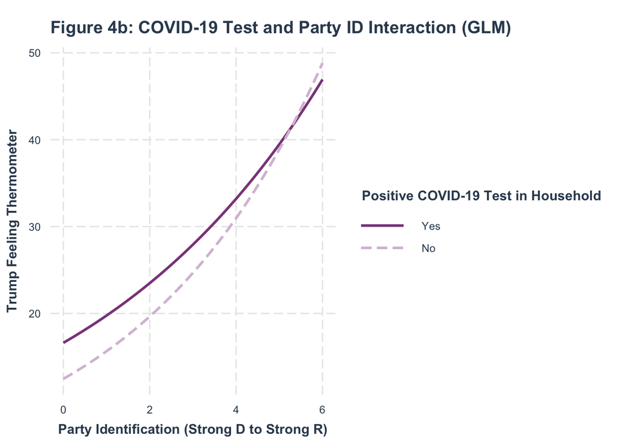

```r
fig.4b <- interact_plot(model.2b,
                        pred=pid,
                        modx=pos_covid,
                        main.title="Figure 4b: COVID-19 Test and Party ID Interaction (GLM)",
                        x.label="Party Identification (Strong D to Strong R)",
                        y.label="Trump Feeling Thermometer",
                        legend.main="Positive COVID-19 Test in Household",
                        modx.labels=c("No", "Yes"),
                        colors=c("thistle","orchid4"))
fig.4b
```

Figure 4b shows the results of the interaction effect between party identification and household positive COVID-19 tests from the generalized linear model. Among strong Democrats, those with positive COVID-19 tests in their households felt slightly more warmly towards Donald Trump than those who did not. Among strong Republicans, however, those who were exposed to positive COVID-19 tests in their households expressed slightly colder attitudes towards Trump than those who did not.

If there is, in fact, a significant interaction between party identification and COVID-19 exposure, the effect appears to be reversed depending on the type of exposure. Symptoms in one’s household make strong Democrats feel colder towards Donald Trump than they would otherwise. Meanwhile, positive COVID-19 tests in one’s household make strong Democrats feel warmer towards Trump than they normally would. The opposite is true for strong Republicans.

## Conclusion

Overall, there is mixed evidence for the impact of personal COVID-19 experiences on attitudes towards Donald Trump. On one hand, it is evident that the pandemic influenced voters’ opinions of Trump. Approval for the former president’s response to the pandemic was one of the most practically significant predictors of warmer overall feelings towards him. However, different measures of COVID-19 exposure yielded different results. Voters with positive COVID-19 tests in their household were likely to have warmer views of Donald Trump than those who did not, while those with COVID-19 symptoms in their households were likely to have colder views of Donald Trump than those who did not.

Even the impact of party identification was different for each measure of party identification. Exposure to COVID-19 symptoms made Democrats and Republicans more polarized on Trump, while exposure to positive COVID-19 tests made them less polarized (i.e. Republicans felt colder towards Trump than usual and Democrats felt warmer than usual).

One obvious limitation of this study is the fact that the ANES’ questions about COVID-19 experiences do not account for severity. We only know whether or not someone in each respondent’s household had COVID-19, based on either symptoms or positive tests. We do not know whether any of the people affected were hospitalized or died, or even whether or not the respondent was one of those affected.

Additionally, the number of respondents in this survey who were exposed to COVID-19 is limited. Out of the 8,280 respondents in the sample, only 998 reported experiencing coronavirus symptoms in their households. Even less respondents (287) reported an actual positive test for COVID-19 in their households. Therefore, these results may not be generalizable to the millions of people in the U.S. who had COVID-19 leading up to the 2020 election. This investigation could be improved by repeating this analysis with a sample that includes more respondents who had personal COVID-19 experiences and more specific questions about their exposure.

## References

American National Election Studies. 2021. “ANES 2020 Time Series Study Full Release [dataset and documentation]: July 19, 2021 version.” *ANES.* https://electionstudies.org/data-center/2020-time-series-study/

United States Census Bureau. 2022. “Geographic Levels: Regions and Divisions.” *United States Census Bureau.* https://www.census.gov/programs-surveys/economic-census/guidance-geographies/levels.html#par_textimage_34